# Enablers of Global Value Chains

Trang Tran

2026-10-13

## GVC reminders

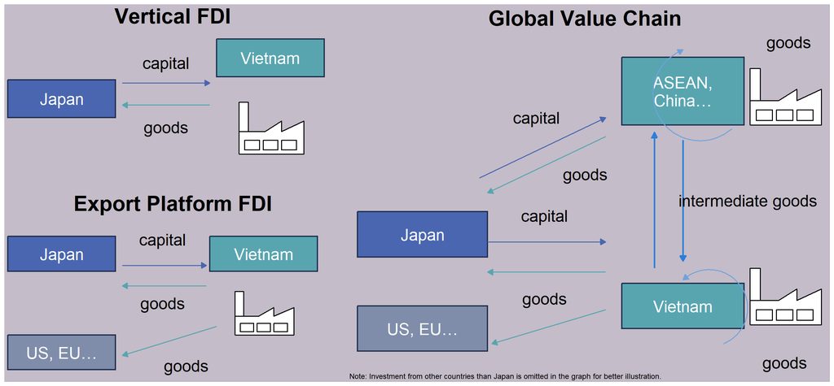

Figure 1: Vertical FDI, export-platform FDI and global value chains

## What make GVCs

- What are the conditions that allow firms to separate production and consumption and different tasks in supply chain ?
- Declining trade costs: trade policy, tariff and non-tariff barrier, transport and logistics
- Declining coordination costs: investment policy, ICT, movement of people, institution

## Effects of Trade Costs on Bilateral Trade

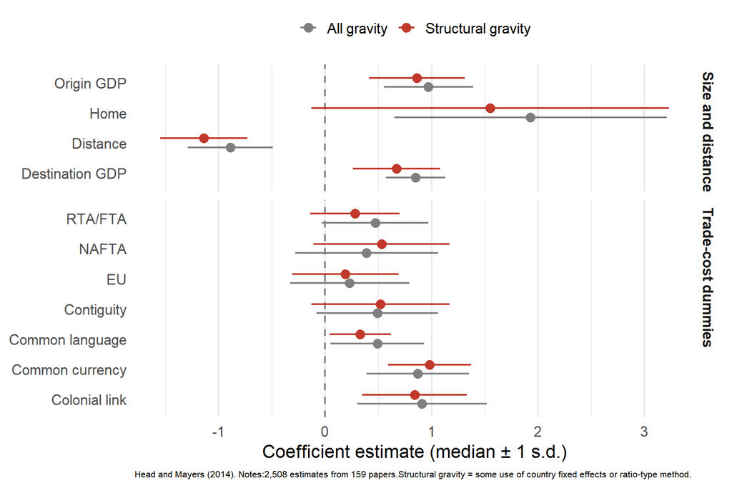

Figure 2: Gravity coefficient estimates

## WTO and multilateralism

## WTO challenge

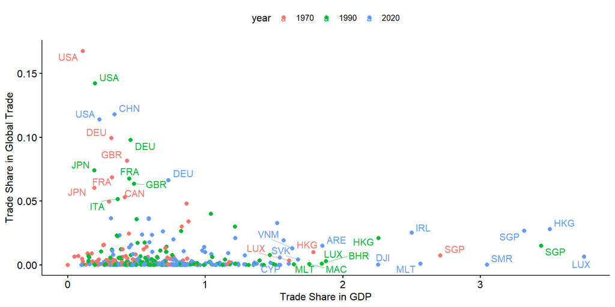

## Regional and bilateral agreements

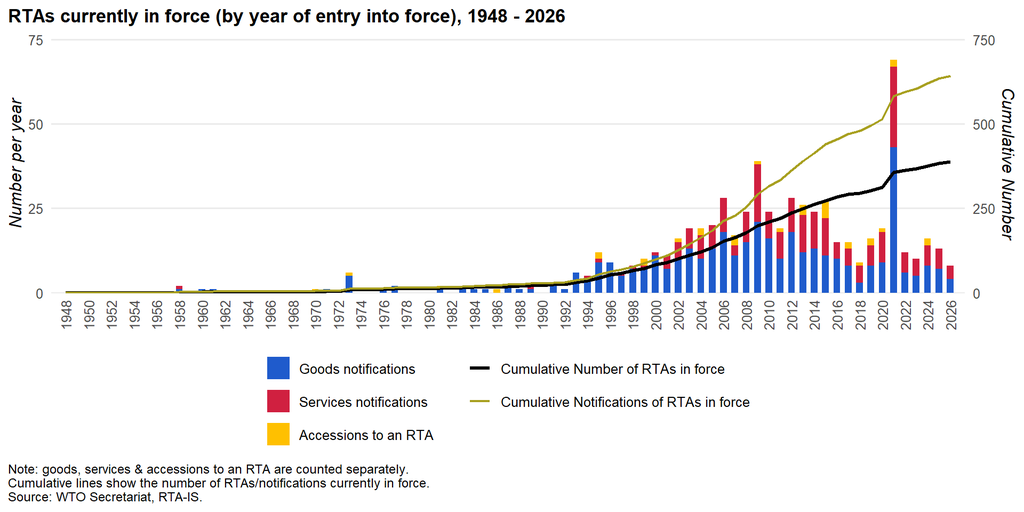

## Regional and bilateral agreements (cont.)

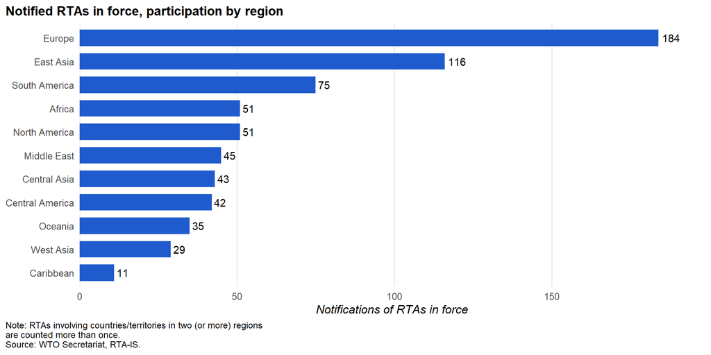

## MFN tariff rates

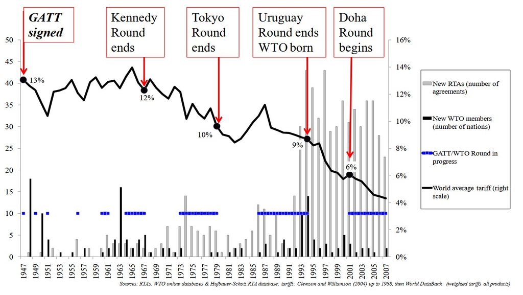

*Source: Baldwin (2011)*

## WTO challenge

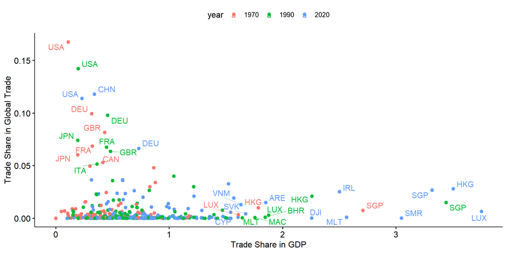

## Regional and bilateral agreements

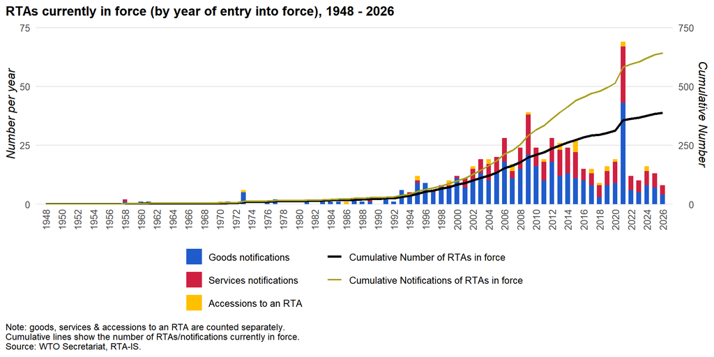

## Regional and bilateral agreements by regions

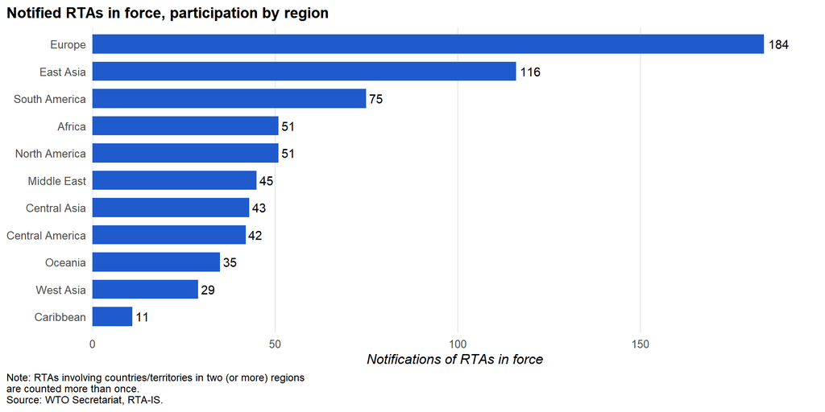

## Average tariff rates

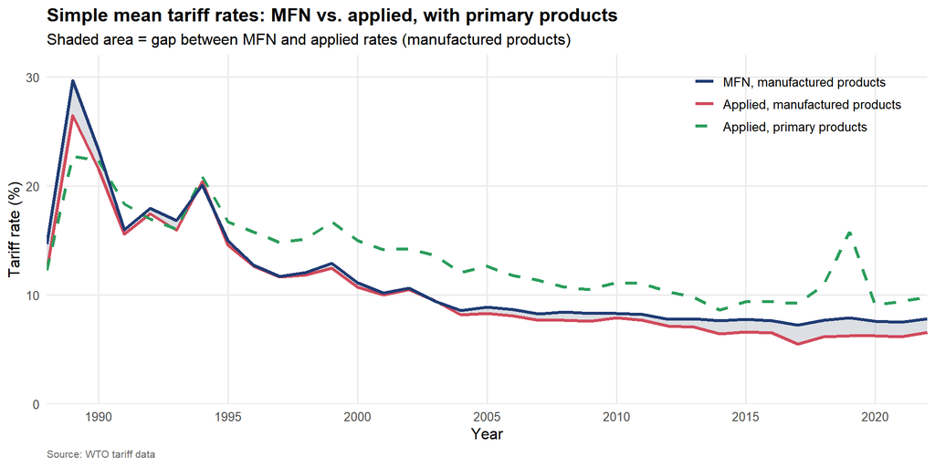

## Japan tariff

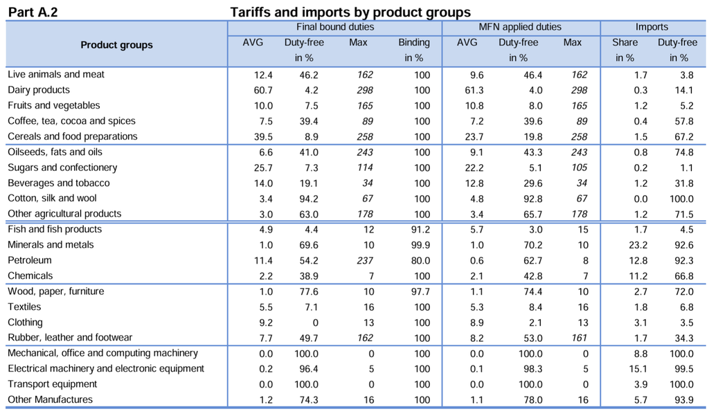

*Source: WTO Tariff Profile (2025)*

## Non-tariff measures

| Technical measures | Non-technical measures | Export measures |
| --- | --- | --- |
| **A. SPS** (pesticide limits) | **D. Trade-protective** (anti-dumping) | **P. Export measures** (export taxes) |
| **B. TBT** (labeling) | E. Licensing, quotas (import bans) |  |
| C. Pre-shipment inspection (customs checks) | F. Price controls (surcharges) |  |
|  | G. Finance (FX controls) |  |
|  | H. Competition (state monopolies) |  |
|  | I. Investment, TRIMs (local content) |  |
|  | J. Distribution (licensed retailers) |  |
|  | K. Post-sales service (local service) |  |
|  | L. Subsidies (farm subsidies) |  |
|  | M. Procurement (buy national) |  |
|  | N. Intellectual property (patents) |  |
|  | O. Rules of origin (origin certificates) |  |

Source: UNCTAD MAST classification

## Non-tariff measures by sector

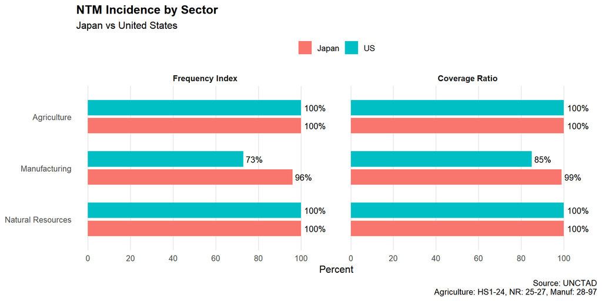

## Non-tariff measures by type

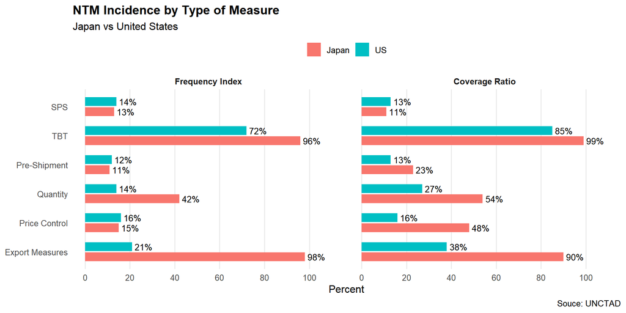

## Tariff equivalence of Non-tariff measures

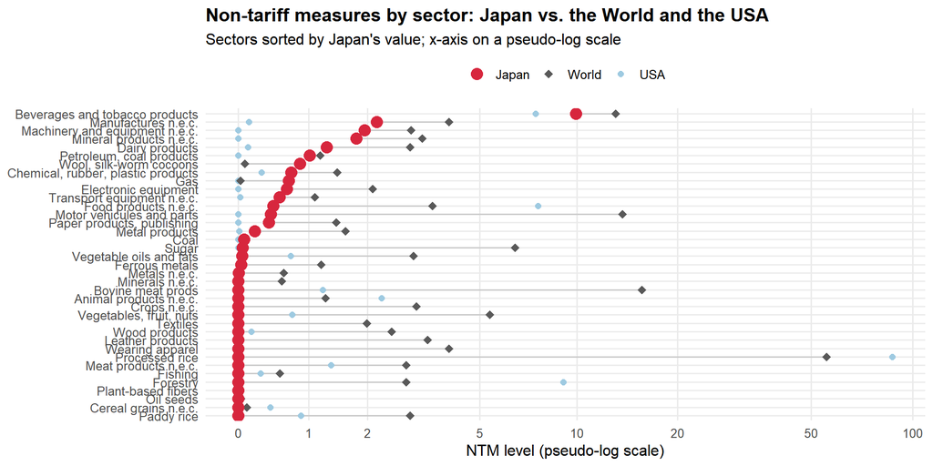

## International transportation costs: Ocean

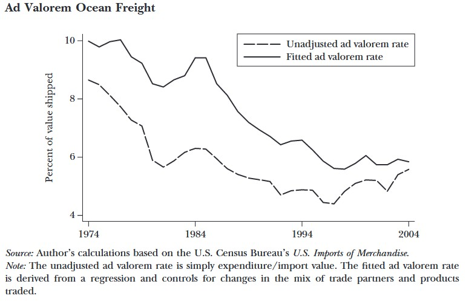

*Source: Hummels (2007)*

## International transportation costs: Air

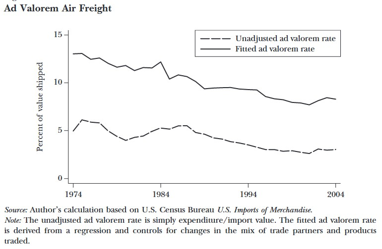

*Source: Hummels (2007)*

## Investment treaties

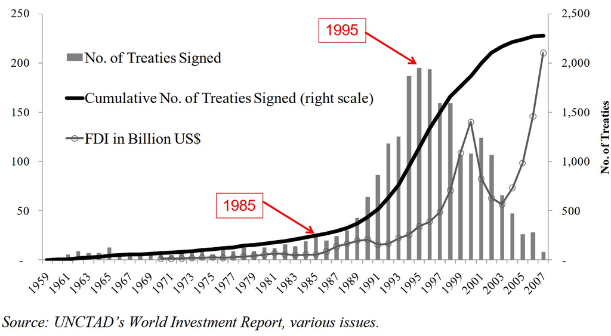

*Source: Baldwin (2011)*

## Export processing zones: entry point into GVCs

- Labor: relatively low wages
- Infrastructure: reliable power, efficient logistics (often next to a port or airport)
- Tax and customs incentives: duty-free inputs, one-stop customs, corporate tax holidays
- Examples: Shenzhen, Bangladesh (Dhaka, Chittagong), Mexico (maquiladoras), Vietnam (Hai Phong, Binh Duong)

## Custom procedures

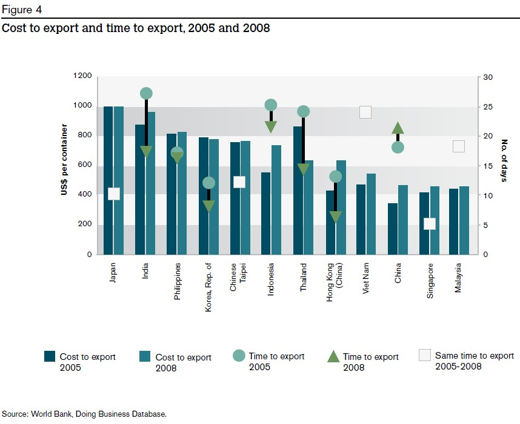

*Source: WTO-IDE (2011)*

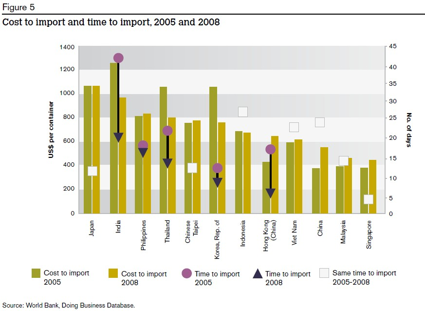

*Source: WTO-IDE (2011)*

## Internet access

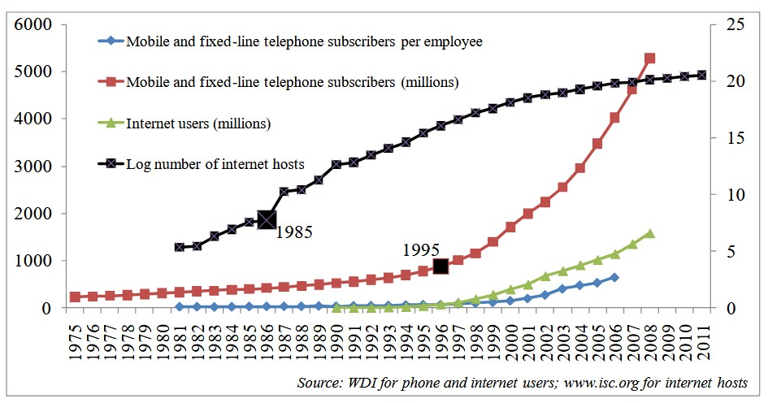

*Source: Baldwin (2011)*

## Key takeaways

- Declining trade costs: trade policy, tariff and non-tariff barrier, transport and logistics
- Declining coordination costs: investment policy, ICT, movement of people, institution

## References

- Baldwin, R. (2011). 21st Century Regionalism: Filling the gap between 21st century trade and 20th century trade rules.
- Head, K., & Mayer, T. (2014). Gravity Equations: Workhorse,Toolkit, and Cookbook. In Handbook of International Economics (Vol. 4, pp. 131–195).
- Hummels, D. (2007). Transportation Costs and International Trade in the Second Era of Globalization. Journal of Economic Perspectives, 21(3), 131–154.
- Kimura and Chen (2016), Implications of Mega Free Trade Agreements for Asian Regional Integration and RCEP Negotiation.
- WTO and JETRO-IDE (2011), Trade patterns and global value chains in East Asia: from trade in goods to trade in tasks.
- Data links
  - https://ttd.wto.org/en
  - https://www.macmap.org/
  - https://www.wto.org/english/res_e/statis_e/tariff_profiles_list_e.htm
  - https://rtais.wto.org/
  - https://unctad.org/topic/trade-analysis/non-tariff-measures/NTMs-data
  - https://wits.worldbank.org/tariff/non-tariff-measures
  - https://datacatalog.worldbank.org/search/dataset/0040437/ad-valorem-equivalent-of-non-tariff-measures